# ‘How does the pattern of disturbance accumulate over time?’

Maximilian H.K. Hesselbarth

17 April, 2020

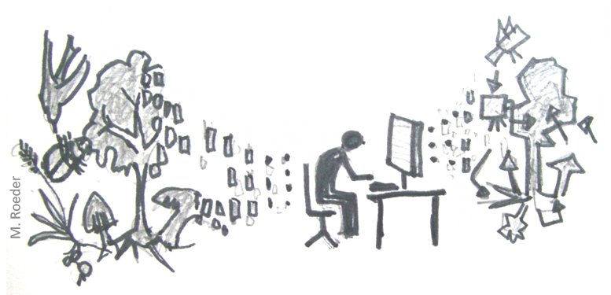

### Introduction

Please be aware and acknowledge that the data was published in: Klaas, B.A., Moloney, K.A., Danielson, B.J., 2000. The tempo and mode of gopher mound production in a tallgrass prairie remnant. Ecography 23, 246–256.

For all further use of the data, a permission of the author must be obtained. We also ask you to not redistribute the data without asking for permission. For further questions about the data, please contact kmoloney@iastate.edu!

### Set-up

First, we load the [`spatstat`](https://spatstat.org) library for spatial point pattern analysis (Baddeley and Turner, 2005). Also, we import the [`tidyverse`](https://www.tidyverse.org) library, a collection of `R` packages designed for data science (Wickham, 2017). To reproduce the analysis we also need to load the [`raster`](https://cran.r-project.org/package=raster) package (Hijmans, 2019) and for an easy arrangment of multiple result plots the [`patchwork`](https://patchwork.data-imaginist.com) package (Pedersen, 2019).

```r
# load packages
library(spatstat)
library(tidyverse)
library(raster)
library(patchwork)
```

If you don’t have the packages installed yet, run the following code in order to install them.

```r
# install packages if not installed yed
install.packages(c("spatstat", "tidyverse", "raster", "patchwork"))
```

Throughout this tutorial, I’m going to use the pipe-operator `%>%`. This allows to redirect (or pipe) the result of a function call directly into the next function. The big advantage of this is that subsequent functions must not be nested and code is much easier to read.

```r
# create 100 random numbers
x <- runif(n = 100)

# calculate the mean of the quantiles
round(mean(quantile(x)), digits = 2)
```

```
## [1] 0.5
```

```r
# same, but much easier to read
x %>%
  quantile() %>%
  mean() %>%
  round(digits = 2)
```

```
## [1] 0.5
```

### Import the data

We use the [`readr`](https://readr.tidyverse.org/index.html) package (Wickham et al., 2018) to import the data to automatically imported is as a [`tibble`](https://tibble.tidyverse.org/index.html) (an advanced `data.frame`; (Müller and Wickham, 2019). For more information see `?tibble`. But, of course you can use any way of importing the data you prefer. The deliminator of the data is a comma. The data is seperated into two .csv-files for the years 1994 and 1995.

The data includes a coloumn with the date of sampling as well as a coloumn which identifies the type of the points (“Elevation”, “New”, “Old”, “Stake”, “Trap”). Afer importing the data, we transform the date coloumn `as.Date` and order the data by `Type` and `Date` in the same pipe.

```r
data_94 <- readr::read_delim("Data/Mounds_94.csv",
                             delim  = ",", col_names = TRUE) %>%
  dplyr::mutate(Date = as.Date(Date, format = "%m/%d/%y")) %>%
  dplyr::arrange(Type, Date)

data_95 <- readr::read_delim("Data/Mounds_95.csv",
                             delim  = ",", col_names = TRUE) %>%
  dplyr::mutate(Date = as.Date(Date, format = "%m/%d/%y")) %>%
  dplyr::arrange(Type, Date)

data_94
```

```
## # A tibble: 735 x 7
##    Date       Type      Location     X     Y Elevation Note
##    <date>     <chr>     <chr>    <dbl> <dbl>     <dbl> <chr>
##  1 1994-07-14 Elevation Anderson  24.2  86.6     0.82  outside
##  2 1994-07-14 Elevation Anderson  35.5  87.0     0.672 outside
##  3 1994-07-14 Elevation Anderson  46.3  86.2     0.436 outside
##  4 1994-07-14 Elevation Anderson  55.3  87.0     0.285 outside
##  5 1994-07-14 Elevation Anderson  66.8  86.6     0.379 outside
##  6 1994-07-14 Elevation Anderson  75.3  84.6     0.637 outside
##  7 1994-07-14 Elevation Anderson  85.7  84.0     0.87  outside
##  8 1994-07-14 Elevation Anderson  85.3  74.6     0.662 outside I8
##  9 1994-07-14 Elevation Anderson  76.2  74.7     0.537 middle of cell
## 10 1994-07-14 Elevation Anderson  65.8  75.1     0.454 middle of cell
## # … with 725 more rows
```

To check the different types of points, we can use the `table()` function. Because we are only interested in the new mounds, we filter the data accordingly and save the result as a subset of the data.

```r
# check different data types
table(data_94$Type, useNA = "ifany")
```

```
##
## Elevation       New       Old     Stake      Trap
##        53       327       212        43       100
```

```r
table(data_95$Type, useNA = "ifany")
```

```
##
##   New Stake  Trap
##   702    60   100
```

```r
# filter new mounds
mounds_new_94 <- dplyr::filter(data_94, Type == "New")
mounds_new_95 <- dplyr::filter(data_95, Type == "New")
```

Firstly, we simply visualize the two point patterns of the north grid in 1994 and 1995. For this, we use the [`ggplot2`](https://ggplot2.tidyverse.org) package (Wickham, 2016). But again, if you prefer you can also use the `base plotting system` to plot the locations of mounds. To also visualize the study plot (also called observation window), we create a `tibble` with the coordinates of the corner points in counter-clockwise order

```r
# coordinates of study plot
study_plot <- tibble::tibble(x = c(0, 80, 80, 0), y = c(0, 0, 80, 80))
```

Next, we can create both ``ggplot`s and combine them into on arrangement using `patchwork`.

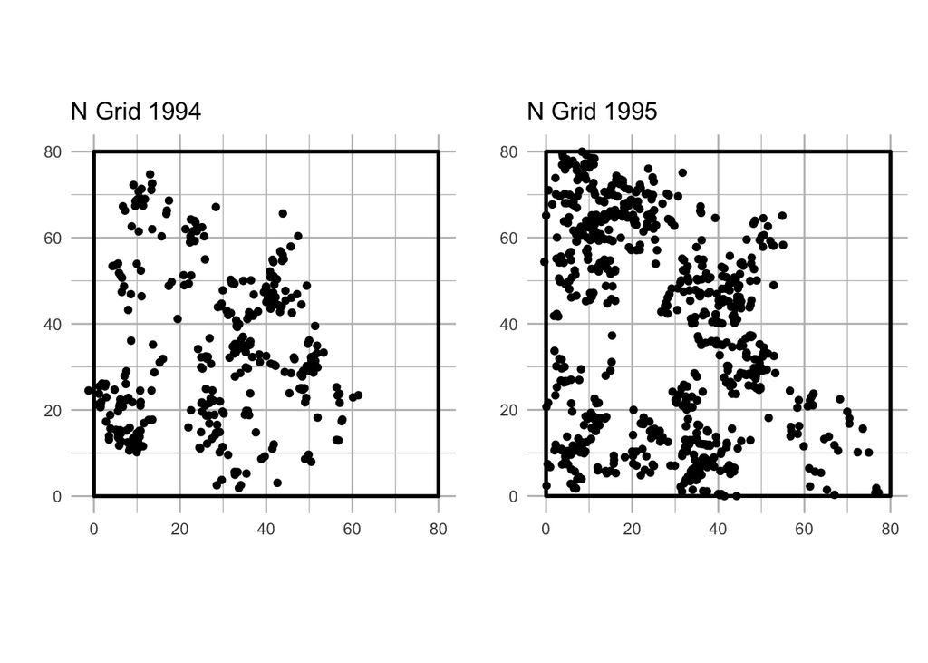

```r
# create plot 1994
mounds_new_94_gg <- ggplot(data = mounds_new_94) +
  geom_point(aes(x = X, y = Y)) +
  geom_polygon(data = study_plot, aes(x = x, y = y), size = 1,
               fill = NA, col = "black") +
  coord_equal() +
  labs(x = "", y = "", title = "N Grid 1994") +
  theme_minimal() +
  theme(panel.grid.major = element_line(colour = "grey"),
        panel.grid.minor = element_line(colour = "grey"))

# create plot 1995
mounds_new_95_gg <- ggplot(data = mounds_new_95) +
  geom_point(aes(x = X, y = Y)) +
   geom_polygon(data = study_plot, aes(x = x, y = y), size = 1,
               fill = NA, col = "black") +
  coord_equal() +
  labs(x = "", y = "", title = "N Grid 1995") +
  theme_minimal() +
  theme(panel.grid.major = element_line(colour = "grey"),
        panel.grid.minor = element_line(colour = "grey"))

# combine to one plot
mounds_new_94_gg + mounds_new_95_gg
```

### Intensity over time

Next, we can calculate the intensity over time. For this, we firstly convert to the `tibble` to a `ppp`-object (point pattern in 2-D plane) of the `spatstat` package. To specify the study plot (called “observation window” in `spatstat`), we can use the previously created `tibble` with the corner coordinates.

```r
# create owin object for study plot
study_plot <- spatstat::owin(poly = study_plot)

# create ppp new mounds
mounds_new_94_ppp <- spatstat::ppp(x = mounds_new_94$X, y = mounds_new_94$Y,
                                   window = study_plot)
mounds_new_95_ppp <- spatstat::ppp(x = mounds_new_95$X, y = mounds_new_95$Y,
                                   window = study_plot)
```

A few points are located slightly outside the defined study plot (probably due to some minor inaccurcies during the sampling). `spatstat` automatically rejects these points and we need to remove those points when we want to add the date as marks to the point pattern (additional characteristics of the points). For this, the `inside.owin()` function can be used to subset the data.

```r
# add marks to points but subsetting points outside study plot
spatstat::marks(mounds_new_94_ppp) <- mounds_new_94$Date[spatstat::inside.owin(x = mounds_new_94$X,
                                                                               y = mounds_new_94$Y,
                                                                               w = study_plot)]

spatstat::marks(mounds_new_95_ppp) <- mounds_new_95$Date[spatstat::inside.owin(x = mounds_new_95$X,
                                                                               y = mounds_new_95$Y,
                                                                               w = study_plot)]
```

As a last step, we `superimpose()` the point pattern of 1994 and 1995 to have one final point pattern.

```r
mounds_new_94_95_ppp <- spatstat::superimpose(mounds_new_94_ppp, mounds_new_95_ppp)
```

Now, we can use the moving window approach to calculate the production rate of mounds per area and time. Therefore, we create a raster grid to later store the rate of production.

```r
grid_plot <- matrix(data = 0, nrow = 80, ncol = 80) %>%
  raster::raster(xmn = 0, xmx = 80,
                 ymn = 0, ymx = 80,
                 crs = NA)
```

To acutally count the number of mounds within each grid cell, we convert this `raster` to a `tibble` to loop through all rows and by that through each raster cell. Within the loop, we create a small `owin` object with the size of 20 $m^{2}$ using the cell centre as the centre of the `owin`. We then count the number of mounds within the small observation window using `inside.owin()` and divide the count by the amount of time and the area.

```r
# convert to dataframe
grid_plot_df <- raster::as.data.frame(grid_plot, xy = TRUE) %>%
  tibble::as_tibble()

# init vector to store results
production_rate <- vector(mode = "numeric", length = nrow(grid_plot_df))

# count mounds in 20qm area
for (i in 1:nrow(grid_plot_df)) {

  # create owin with 20qm around cell center
  owin_temp <-  spatstat::owin(xrange = c(grid_plot_df[[i, 1]] - sqrt(5),
                                          grid_plot_df[[i, 1]] + sqrt(5)),
                               yrange = c(grid_plot_df[[i, 2]] - sqrt(5),
                                          grid_plot_df[[i, 2]] + sqrt(5)))

  # T/F for points inside
  points_inside_temp <- spatstat::inside.owin(x = mounds_new_94_95_ppp$x,
                                              y = mounds_new_94_95_ppp$y,
                                              w = owin_temp)

  # count number of trues divided by sample area and time
  production_rate[i] <- sum(points_inside_temp) / 20 / 2
}
```

Lastly, we can add the calculated production rate to the `raster` and/or the `tibble` and plot the result using either `ggplot2` or the `raster` plotting function

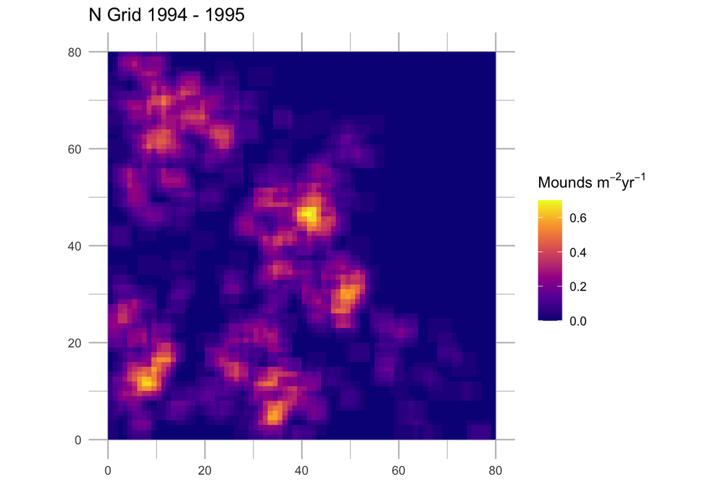

```r
# add value to df
grid_plot_df$layer <- production_rate

# add value to raster
raster::values(grid_plot) <- production_rate

# plot result
ggplot(data = grid_plot_df) +
  geom_raster(aes(x = x, y = y, fill = layer)) +
  scale_fill_viridis_c(option = "C",
                       name = expression(paste("Mounds ", m^{-2}, yr^{-1}))) +
  coord_equal() +
  labs(x = "", y = "", title = "N Grid 1994 - 1995") +
  theme_minimal() +
  theme(panel.grid.major = element_line(colour = "grey"),
        panel.grid.minor = element_line(colour = "grey"))
```

### Pooled L-function

To analyse the L-function for the pooled data set (both years combined), we firstly clip the study plot by removing the area that was flooded previously to the field season of sampling. Because we don’t know the exact locations of this area, we have to estimated it by try-and-error.

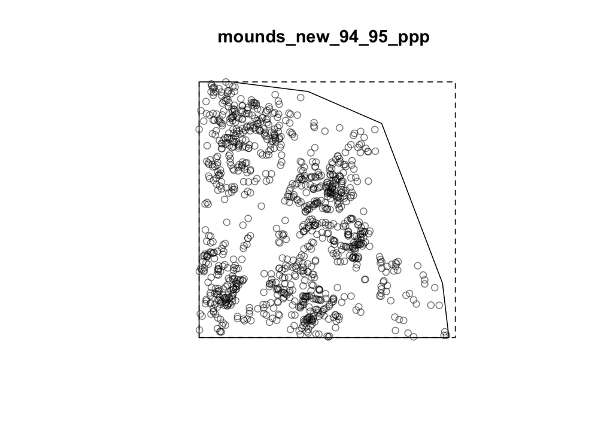

```r
# new observation window w/o area with no mounds
study_plot_clipped <- tibble::tibble(x = c(0, 78, 76, 57, 34, 10, 0),
                                     y = c(0, 0 , 17, 67, 77, 80, 80))

# replace window
mounds_new_94_95_ppp$window <-  spatstat::owin(poly = study_plot_clipped)

# plot point pattern
plot(mounds_new_94_95_ppp, use.marks = FALSE)

# add old observation window
plot(study_plot, add = TRUE, lty = 2)
```

In the original publication, the centered L-function was used. However, in `spatstat` only the “normal” L-function (Besag 1977) is available. Thus, we need to center it ourselves. The `eval.fv()` functions allows to evaluate any expression involving the result of a previously calculated summary function in `spatstat` (`fv` object). Alternativly, you could also use the `center_l_function()` function from the [`onpoint`](https://r-spatialecology.github.io/onpoint/) package (Hesselbarth, 2019).

```r
l_center <- function(x, ...) {

  # calculate L function
  x <- spatstat::Lest(x, ...)

  # get r value
  r <- x$r

  # center L-function by r value
  l_centered <- spatstat::eval.fv(x - r)

  return(l_centered)
}
```

To calculate the 5th highest and lowest values of the null model data (simulation envelope) and the observed function value, we use the `envelope()` function. If we do not specify a certain null model, complete spatial randomness (CSR) is simulated automatically. The `envelope()` function also allows to specify some more arguments such as the `correction` or the scales `r`. When plotting the results, we need to use the same limits of the x- and y-axis as in the original publication.

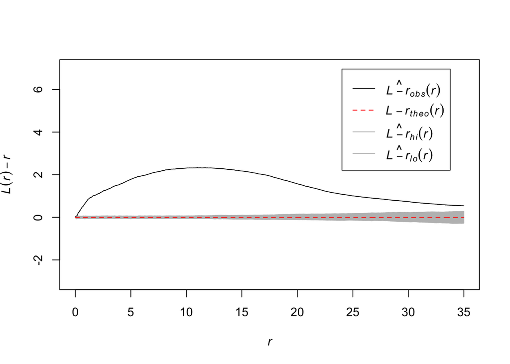

```r
# calculate CSR envelopes
envelopes_l_fun <- spatstat::envelope(Y = mounds_new_94_95_ppp,
                                      fun = l_center,
                                      funargs = list(r = seq(from  = 0, to = 35, length.out = 525),
                                                     correction = "Ripley"),
                                      nsim = 199, nrank = 5,
                                      verbose = FALSE)

# plot results
plot(envelopes_l_fun, xlim = c(0, 35), ylim = c(-3, 7), main = "")
```

### References

Baddeley, A., Turner, R., 2005. spatstat: An R package for analyzing spatial point patterns. J. Stat. Softw. 12, 1–42.

Besag, J.E., 1977. Discussion on Dr. Ripley’s paper. J. R. Stat. Soc. Ser. B Methodol. 39, 193–195.

Hesselbarth, M.H.K., 2019. onpoint: Helper functions for point pattern analysis. R package version 0.2.1.

Hijmans, R.J., 2019. raster: Geographic data analysis and modeling. R package version 2.9-5. https://cran.r-project.org/package=raster.

Klaas, B.A., Moloney, K.A., Danielson, B.J., 2000. The tempo and mode of gopher mound production in a tallgrass prairie remnant. Ecography 23, 246–256.

Müller, K., Wickham, H., 2019. tibble: Simple Data Frames. R package version 2.1.3.

Pedersen, T., 2019. patchwork: The Composer of Plots. R package version 1.0.0. https://CRAN.R-project.org/package=patchwork.

Wickham, H., 2017. tidyverse: Easily Install and Load the “Tidyverse”. R package version 1.2.1.

Wickham, H., 2016. ggplot2: Elegant graphics for data analysis. Springer, New York.

Wickham, H., Hester, J., Francois, R., 2018. readr: Read Rectangular Text Data. R package version 1.3.1.

[Maximilian H.K. Hesselbarth](https://mhesselbarth.rbind.io/)

*maximilian.hesselbarth@uni-goettingen.de*